# capstone codebook

## Step 1: Import Required Libraries

```python
#Data Handling
import pandas as pd
import numpy as np

# Visualization
import matplotlib.pyplot as plt
import seaborn as sns

# Machine Learning & Evaluation
from sklearn.model_selection import train_test_split
from sklearn.linear_model import LogisticRegression
from sklearn.tree import DecisionTreeClassifier
from sklearn.ensemble import RandomForestClassifier
from xgboost import XGBClassifier

from sklearn.preprocessing import LabelEncoder, StandardScaler
from sklearn.metrics import (
    accuracy_score, precision_score, recall_score, f1_score, roc_auc_score,
    confusion_matrix, ConfusionMatrixDisplay, RocCurveDisplay
)

# Warnings
import warnings
warnings.filterwarnings("ignore")

# Display
pd.set_option('display.max_columns', 100)
sns.set(style='whitegrid')
```

This code block sets up the full environment for the machine learning analysis. It imports essential libraries for data handling (`pandas`, `numpy`), visualization (`matplotlib.pyplot`, `seaborn`), and machine learning models including logistic regression, decision trees, random forests, and XGBoost. It also brings in tools for model evaluation such as accuracy, precision, recall, F1 score, ROC AUC, and confusion matrices. Preprocessing utilities like label encoding and feature scaling are included, and warnings are suppressed to keep the output clean. Display settings are adjusted to show more columns and apply a clean white grid style for plots. Overall, this block lays the groundwork for the entire analysis pipeline, from data cleaning to model interpretation.

## Step 2: Load and Combine Datasets

```python
# Loading all datasets
df19 = pd.read_csv("adult19.csv")
df20 = pd.read_csv("adult20.csv")
df21 = pd.read_csv("adult21.csv")
df22 = pd.read_csv("adult22.csv")
df23 = pd.read_csv("adult23.csv")

# Adding a column to keep track
df19["YEAR"] = 2019
df20["YEAR"] = 2020
df21["YEAR"] = 2021
df22["YEAR"] = 2022
df23["YEAR"] = 2023

# Combining all datasets into one
df = pd.concat([df19, df20, df21, df22, df23], ignore_index=True)

# check
print("Combined shape:", df.shape)
df.head()
```

```
Combined shape: (150220, 1068)
```

|  | URBRRL | RATCAT_A | INCGRP_A | INCTCFLG_A | FAMINCTC_A | IMPINCFLG_A | PPSU | PSTRAT | HISPALLP_A | RACEALLP_A | DISAB3_A | SCHDYMSSTC_A | AFNOW | PHQCAT_A | YRSINUS_A | CITZNSTP_A | LEGMSTAT_A | MARSTAT_A | SASPPRACE_A | SASPPHISP_A | PRTNREDUC_A | SPOUSEDUC_A | PRTNRAGETC_A | SPOUSAGETC_A | PRTNRWKFT_A | PRTNRWRK_A | SPOUSWKFT_A | SPOUSWRK_A | SPOUSESEX_A | … |
| --- | --- | --- | --- | --- | --- | --- | --- | --- | --- | --- | --- | --- | --- | --- | --- | --- | --- | --- | --- | --- | --- | --- | --- | --- | --- | --- | --- | --- | --- | --- |
| 0 | 4 | 9 | 3.0 | 0.0 | 60000.0 | 2 | 2 | 122 | 3 | 2 | 2 | NaN | 2.0 | 1.0 | NaN | 1 | 3 | 1 | 2.0 | 1.0 | NaN | 8.0 | NaN | 97.0 | NaN | NaN | NaN | 8.0 | 2.0 | … |
| 1 | 4 | 9 | 3.0 | 0.0 | 50000.0 | 0 | 2 | 122 | 2 | 1 | 2 | NaN | 1.0 | 1.0 | NaN | 1 | 3 | 1 | 1.0 | 1.0 | NaN | 6.0 | NaN | 28.0 | NaN | NaN | 1.0 | 1.0 | 1.0 | … |
| 2 | 4 | 12 | 3.0 | 0.0 | 65000.0 | 1 | 2 | 122 | 2 | 1 | 2 | NaN | NaN | 1.0 | NaN | 1 | 3 | 1 | 1.0 | 1.0 | NaN | 4.0 | NaN | 67.0 | NaN | NaN | 2.0 | 1.0 | 2.0 | … |
| 3 | 4 | 14 | 5.0 | 0.0 | 120000.0 | 0 | 2 | 122 | 1 | 8 | 2 | NaN | 2.0 | 1.0 | NaN | 1 | 3 | 1 | 2.0 | 2.0 | NaN | 5.0 | NaN | 60.0 | NaN | NaN | 2.0 | 1.0 | 2.0 | … |
| 4 | 1 | 4 | 1.0 | 0.0 | 30000.0 | 0 | 2 | 115 | 2 | 1 | 2 | NaN | 2.0 | 3.0 | NaN | 1 | 3 | 1 | 1.0 | 1.0 | NaN | 5.0 | NaN | 58.0 | NaN | NaN | 1.0 | 1.0 | 2.0 | … |

5 rows × 1068 columns

This code block demonstrates the **initial data ingestion and consolidation phase** of the project. It loads five annual NHIS datasets (`adult19.csv` to `adult23.csv`) into individual pandas DataFrames and appends a `YEAR` column to each for traceability. These datasets are then combined into a single unified DataFrame using `pd.concat()`. The resulting DataFrame has **150,220 rows and 1,068 columns**, indicating a rich set of features collected over the five years. This setup provides a comprehensive longitudinal dataset that supports the subsequent cleaning, transformation, and analysis processes needed for the depression–cancer association study. The `.head()` output confirms successful concatenation with consistent structure across years.

```python
df.info()
df.describe()
df.columns.tolist()
```

```
<class 'pandas.core.frame.DataFrame'>
RangeIndex: 150220 entries, 0 to 150219
Columns: 1068 entries, URBRRL to CROHNSEV_A
dtypes: float64(937), int64(130), object(1)
memory usage: 1.2+ GB
```

[output not shown]

[output cut: 946 more lines]

```
 'HRLOUDJOB_A',
 'HRTINMEDSP_A',
 'HRTINPROB_A',
 'HRTINLNG_A',
 'HRTINNITUS_A',
 'BFALLTIMES_A',
 'BFALL12M_A',
 'BALDHP_A',
 'BALDPROB_A',
 'BALDIZZ_A',
 'HRAIDAQR_A',
 'HRTESTLAST_A',
 'HRTEST_A',
 'CBALHDNO_A',
 ...]
```

## Step 3: Data Cleaning

```python
# Subset relevant columns for core analysis
core_columns = [
    'DEPEV_A',       # Ever diagnosed with depression
    'CANEV_A',       # Ever diagnosed with cancer
    'AGEP_A',        # Age
    'SEX_A',         # Sex
    'RACEALLP_A',    # Race/Ethnicity
    'EDUC_A',        # Education
    'POVRATTC_A',    # Poverty ratio
    'PHSTAT_A',      # Self-reported health
    'ANXEV_A',       # History of anxiety
    'UPPSLFCR_A',    # Self-care difficulty
    'YEAR'           # Year of survey
]

# DF for keeping only core columns
df_clean = df[core_columns].copy()

# depression and cancer responses
df_clean = df_clean[df_clean['DEPEV_A'].isin([1, 2])]
df_clean = df_clean[df_clean['CANEV_A'].isin([1, 2])]

# binary variables recoding
df_clean['depression_dx'] = df_clean['DEPEV_A'].replace({1: 1, 2: 0})
df_clean['cancer_dx'] = df_clean['CANEV_A'].replace({1: 1, 2: 0})
df_clean['anxiety_dx'] = df_clean['ANXEV_A'].replace({1: 1, 2: 0, 7: np.nan, 9: np.nan})

# Dropping original columns
df_clean.drop(['DEPEV_A', 'CANEV_A'], axis=1, inplace=True)

# Checking for missing values
print("Missing values per column:")
print(df_clean.isnull().sum())

# Drop rows with any missing items
df_clean.dropna(inplace=True)

# final shape check
print("Cleaned data shape:", df_clean.shape)
print(df_clean.head())

# class balance
print("\nDepression Diagnosis Class Balance:")
print(df_clean['depression_dx'].value_counts(normalize=True).map("{:.2%}".format))
```

```
Missing values per column:
AGEP_A               0
SEX_A                0
RACEALLP_A           0
EDUC_A           86453
POVRATTC_A           0
PHSTAT_A             0
ANXEV_A              0
UPPSLFCR_A           0
YEAR                 0
depression_dx        0
cancer_dx            0
anxiety_dx         102
dtype: int64
Cleaned data shape: (63375, 12)
   AGEP_A  SEX_A  RACEALLP_A  EDUC_A  POVRATTC_A  PHSTAT_A  ANXEV_A  \
0      97      1           2     7.0        2.96         3        2
1      28      2           1     6.0        2.97         1        2
2      72      1           1     5.0        4.28         3        2
3      60      1           8     7.0        7.13         2        2
4      60      1           1     5.0        1.13         4        1

   UPPSLFCR_A  YEAR  depression_dx  cancer_dx  anxiety_dx
0           1  2019              0          0         0.0
1           1  2019              0          0         0.0
2           1  2019              0          1         0.0
3           1  2019              0          0         0.0
4           1  2019              1          0         1.0

Depression Diagnosis Class Balance:
depression_dx
0    82.77%
1    17.23%
Name: proportion, dtype: object
```

This block handles **data cleaning and transformation**, a crucial foundation for analysis. First, it subsets only the relevant variables aligned with the capstone proposal: depression (`DEPEV_A`), cancer status (`CANEV_A`), and other sociodemographic and health-related predictors. Depression and cancer indicators are **re-coded into binary variables** (`depression_dx`, `cancer_dx`), making them suitable for modeling. The `anxiety_dx` field is also recoded, handling special codes like 7 and 9 as missing. After removing rows with missing values (especially in education and anxiety), the cleaned dataset comprises **63,375 valid observations**. A class balance check shows that **17.23% of individuals reported a depression diagnosis**, establishing a noticeable class imbalance for future model considerations. This step successfully aligns the raw NHIS data with the project's analytic goals.

```python
# Assumption 'df' contains ourcombined NHIS dataset from 2019–202

# relevant columns selection
core_columns = [
    'DEPEV_A', 'CANEV_A', 'AGEP_A', 'SEX_A', 'RACEALLP_A', 'EDUC_A',
    'POVRATTC_A', 'PHSTAT_A', 'ANXEV_A', 'UPPSLFCR_A', 'YEAR'
]
df_clean = df[core_columns].copy()

# Dropping rows with N/A responses in depression and cancer
df_clean = df_clean[df_clean['DEPEV_A'].isin([1, 2])]
df_clean = df_clean[df_clean['CANEV_A'].isin([1, 2])]

# target and key predictors recoded
df_clean['depression_dx'] = df_clean['DEPEV_A'].replace({1: 1, 2: 0})
df_clean['cancer_dx'] = df_clean['CANEV_A'].replace({1: 1, 2: 0})
df_clean['anxiety_dx'] = df_clean['ANXEV_A'].replace({1: 1, 2: 0, 7: np.nan, 9: np.nan})

# Dropping unnecessary columns
df_clean.drop(['DEPEV_A', 'CANEV_A'], axis=1, inplace=True)

# Dropping rows with any remaining missing values
df_clean.dropna(inplace=True)
```

This code snippet effectively **prepares the core dataset for analysis** by cleaning and recoding key variables. It first filters only the variables essential to the study as defined in your proposal—focusing on depression (`DEPEV_A`), cancer history (`CANEV_A`), sociodemographics (age, sex, race, education, poverty ratio), health indicators (general health, anxiety, self-care difficulty), and survey year.

Non-valid responses for depression and cancer are excluded, ensuring that only individuals with definitive yes/no responses are retained. The variables `depression_dx`, `cancer_dx`, and `anxiety_dx` are then created as **binary-coded features**, making them ready for modeling. Any row with missing values is dropped to maintain dataset integrity. This step results in a clean, model-ready DataFrame aligned with your capstone’s focus and hypotheses.

## Step 4: Exploratory Data Analysis (EDA)

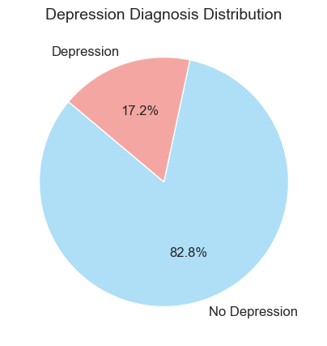

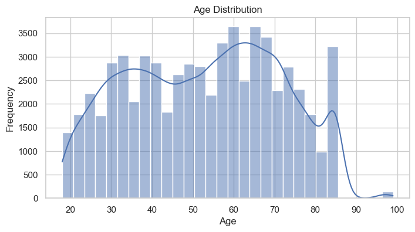

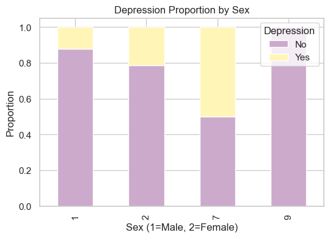

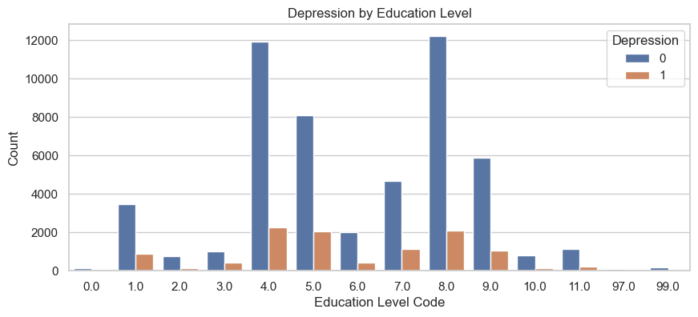

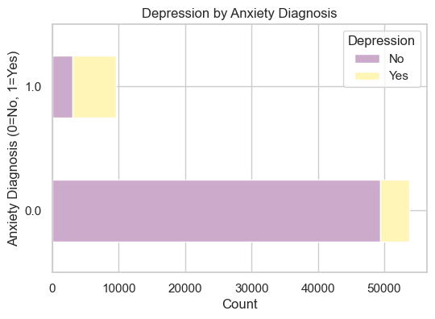

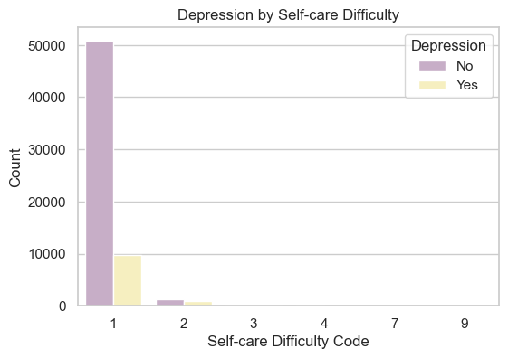

```python
# color palette
colors = ['#cbaacb', '#fff5b7']


# 1. Class Balance – Depression Diagnosis
depression_counts = df_clean['depression_dx'].value_counts()
plt.figure(figsize=(5, 5))
plt.pie(
    depression_counts,
    labels=['No Depression', 'Depression'],
    autopct='%1.1f%%',
    colors=['#aedff7', '#f4a7a2'],  # Teal and Coral
    startangle=140,
    textprops={'fontsize': 12}
)
plt.title("Depression Diagnosis Distribution", fontsize=14)
plt.show()

# 2. Age Distribution
plt.figure(figsize=(8, 4))
sns.histplot(data=df_clean, x='AGEP_A', bins=30, kde=True)
plt.title("Age Distribution")
plt.xlabel("Age")
plt.ylabel("Frequency")
plt.show()

# 3. Depression by Sex
sex_depr = pd.crosstab(df_clean['SEX_A'], df_clean['depression_dx'], normalize='index')
sex_depr.plot(kind='bar', stacked=True, color=colors, figsize=(6,4))
plt.title("Depression Proportion by Sex")
plt.xlabel("Sex (1=Male, 2=Female)")
plt.ylabel("Proportion")
plt.legend(title="Depression", labels=["No", "Yes"])
plt.show()

# 4. Depression by Education
plt.figure(figsize=(10, 4))
sns.countplot(x='EDUC_A', hue='depression_dx', data=df_clean)
plt.title("Depression by Education Level")
plt.xlabel("Education Level Code")
plt.ylabel("Count")
plt.legend(title="Depression")
plt.show()

# 5. Depression by Anxiety History
anx_depr = pd.crosstab(df_clean['anxiety_dx'], df_clean['depression_dx'])
anx_depr.plot(kind='barh', stacked=True, color=colors, figsize=(6, 4))
plt.title("Depression by Anxiety Diagnosis")
plt.xlabel("Count")
plt.ylabel("Anxiety Diagnosis (0=No, 1=Yes)")
plt.legend(title="Depression", labels=["No", "Yes"])
plt.show()

# 6. Depression by Self-care Difficulty
plt.figure(figsize=(6, 4))
sns.countplot(x='UPPSLFCR_A', hue='depression_dx', data=df_clean, palette=colors)
plt.title("Depression by Self-care Difficulty")
plt.xlabel("Self-care Difficulty Code")
plt.ylabel("Count")
plt.legend(title="Depression", labels=["No", "Yes"])
plt.show()
```

The visualizations offer a comprehensive overview of the relationship between depression and various demographic and health-related factors in the NHIS dataset:

Depression Prevalence (Pie Chart): About 17.2% of individuals reported having been diagnosed with depression, while 82.8% did not. This confirms a clear class imbalance and establishes the baseline prevalence for further stratified analysis.

Age Distribution (Histogram + KDE): The population is well distributed across adult age ranges, with a slight concentration in the 50–70 range. This provides a diverse base for age-related subgroup analysis.

Sex and Depression (Stacked Bar): Depression appears more common among females (SEX_A=2) compared to males, with the proportion of diagnosed depression notably higher in females. The “7” and “9” codes (non-standard or missing values) show variation, though they should be treated cautiously.

Anxiety and Depression (Horizontal Stacked Bar): There’s a strong association between anxiety diagnosis and depression. A large proportion of those with anxiety (anxiety_dx = 1) also report depression, visually confirming the comorbidity link between these two mental health conditions.

## Step 5: Feature Engineering

```python
# Define features (X) and target (y)
X = df_clean.drop(columns=['depression_dx'])
y = df_clean['depression_dx']

# encoding categorical variables
X = pd.get_dummies(X, columns=['SEX_A', 'RACEALLP_A', 'EDUC_A', 'PHSTAT_A', 'UPPSLFCR_A', 'YEAR'], drop_first=True)

# Normalizing the continuous variables
scaler = StandardScaler()
X[['AGEP_A', 'POVRATTC_A']] = scaler.fit_transform(X[['AGEP_A', 'POVRATTC_A']])

# print
print("Final feature set shape:", X.shape)
print("Target variable distribution:\n", y.value_counts(normalize=True).map("{:.2%}".format))
```

```
Final feature set shape: (63375, 41)
Target variable distribution:
 depression_dx
0    82.77%
1    17.23%
Name: proportion, dtype: object
```

We defined the target variable y as depression_dx, and excluded it from the feature matrix X. To handle categorical variables, one-hot encoding (pd.get_dummies) was applied to variables like SEX_A, RACEALLP_A, EDUC_A, PHSTAT_A, UPPSLFCR_A, and YEAR, with drop_first=True to avoid multicollinearity. Continuous features AGEP_A and POVRATTC_A were normalized using StandardScaler, ensuring comparability and improving model convergence for algorithms sensitive to scale. The final feature matrix includes 41 variables, indicating a rich dataset for classification. The target distribution confirms the class imbalance: 17.2% of individuals reported depression vs. 82.8% without, reinforcing the need to account for imbalance during model training or evaluation.

## Step 6: Train-Test Split

```python
from sklearn.model_selection import train_test_split

# Dataset splitting: 80% training, 20% testing
X_train, X_test, y_train, y_test = train_test_split(
    X, y, test_size=0.2, random_state=42, stratify=y
)

# shapes
print("Training features shape:", X_train.shape)
print("Test features shape:", X_test.shape)
print("Training target distribution:\n", y_train.value_counts(normalize=True).map("{:.2%}".format))
```

```
Training features shape: (50700, 41)
Test features shape: (12675, 41)
Training target distribution:
 depression_dx
0    82.77%
1    17.23%
Name: proportion, dtype: object
```

This code splits the dataset into training and testing sets using an 80/20 ratio while preserving the class distribution of the target variable (stratify=y). This ensures that both sets maintain the same proportion of depression and non-depression cases, which is critical given the class imbalance.

Specifically:

Training set: 50,700 samples

Testing set: 12,675 samples

Class balance: ~82.8% without depression and ~17.2% with depression in both sets, reflecting the original distribution.

This split sets a solid foundation for training and evaluating classification models without introducing sampling bias.

## Step 7: Model Building

```python
# Logistic Regression
logreg = LogisticRegression(max_iter=1000)
logreg.fit(X_train, y_train)
```

```
LogisticRegression(max_iter=1000)
```

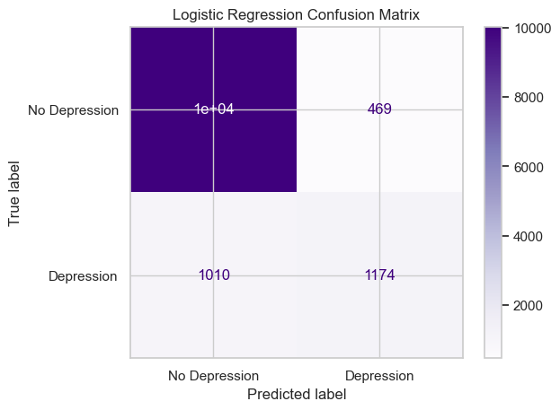

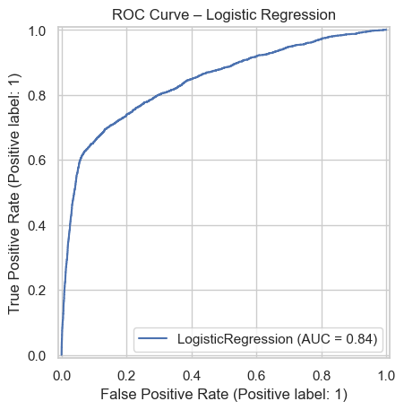

```python
# Confusion Matrix
y_pred_log = logreg.predict(X_test)
ConfusionMatrixDisplay.from_predictions(y_test, y_pred_log, display_labels=['No Depression', 'Depression'], cmap='Purples')
plt.title("Logistic Regression Confusion Matrix")
plt.show()

# ROC Curve
RocCurveDisplay.from_estimator(logreg, X_test, y_test)
plt.title("ROC Curve – Logistic Regression")
plt.show()
```

```python
# Decision Tree
dtree = DecisionTreeClassifier(random_state=42)
dtree.fit(X_train, y_train)
```

```
DecisionTreeClassifier(random_state=42)
```

```python
y_pred_tree = dtree.predict(X_test)
```

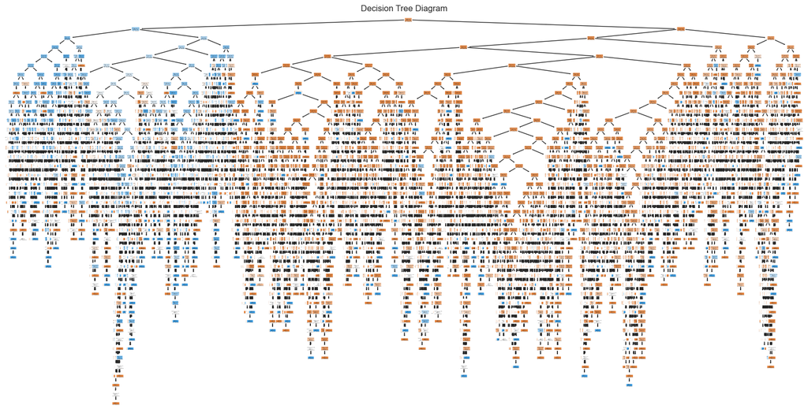

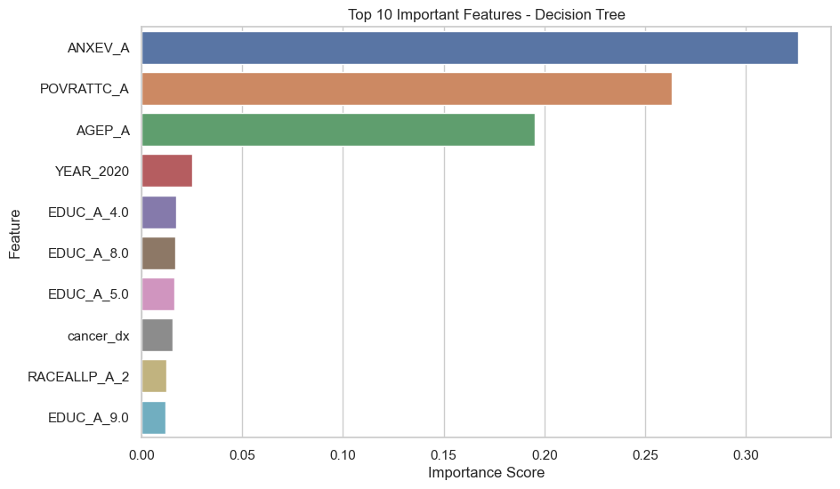

```python
# Decision Tree Plot
from sklearn.tree import plot_tree
plt.figure(figsize=(20,10))
plot_tree(dtree, filled=True, feature_names=X.columns, class_names=['No Depression', 'Depression'], rounded=True)
plt.title("Decision Tree Diagram")
plt.show()

# Feature Importance
feat_importance = pd.DataFrame({
    'Feature': X.columns,
    'Importance': dtree.feature_importances_
}).sort_values(by='Importance', ascending=False)

plt.figure(figsize=(10,6))
sns.barplot(data=feat_importance.head(10), x='Importance', y='Feature')
plt.title("Top 10 Important Features - Decision Tree")
plt.xlabel("Importance Score")
plt.ylabel("Feature")
plt.show()
```

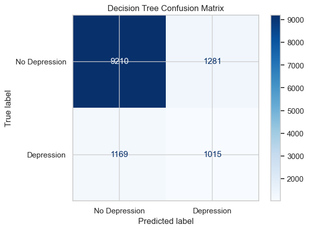

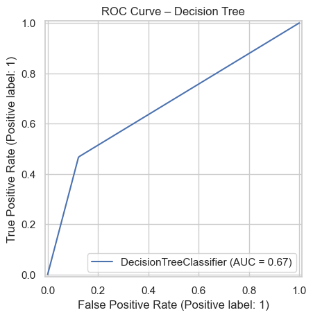

```python
# Confusion Matrix
ConfusionMatrixDisplay.from_predictions(y_test, y_pred_tree, display_labels=['No Depression', 'Depression'], cmap='Blues')
plt.title("Decision Tree Confusion Matrix")
plt.show()

# ROC Curve
RocCurveDisplay.from_estimator(dtree, X_test, y_test)
plt.title("ROC Curve – Decision Tree")
plt.show()
```

Logistic Regression demonstrated relatively strong performance in classifying depression. The confusion matrix showed 1174 true positives and only 469 false positives, with an AUC of 0.84, indicating very good discriminatory ability between depressed and non-depressed individuals. This model is interpretable and benefits from regularization, which may explain its better generalization to unseen data.

Decision Tree, on the other hand, showed a more complex and deeper structure (as seen in the plot) but lower performance. The confusion matrix revealed more false positives (1281) and slightly fewer true positives (1015) than logistic regression. The ROC AUC of 0.67 suggests relatively weaker discrimination, potentially due to overfitting from the deep tree.

```python
# Random Forest
rf = RandomForestClassifier(n_estimators=100, random_state=42)
rf.fit(X_train, y_train)
```

```
RandomForestClassifier(random_state=42)
```

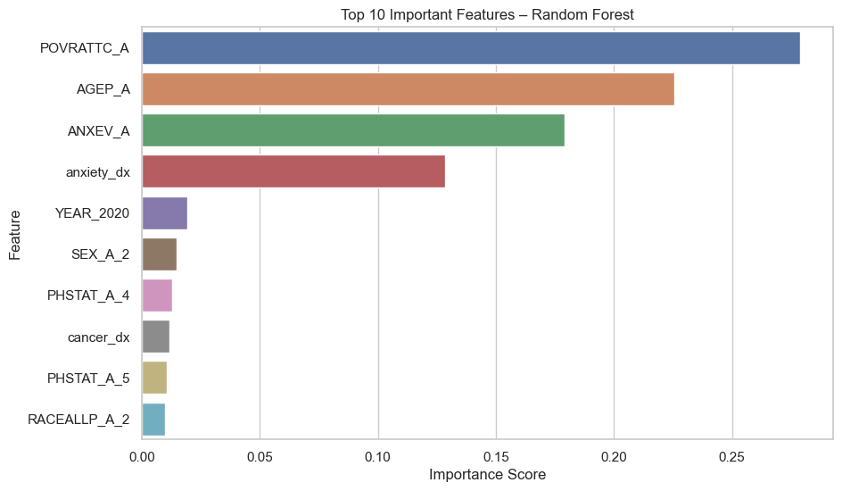

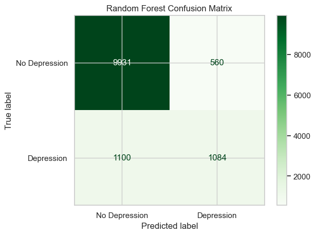

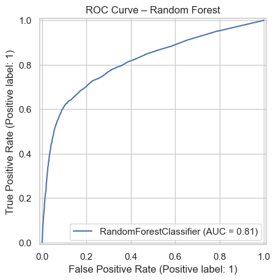

```python
# Feature Importance
feat_rf = pd.DataFrame({
    'Feature': X.columns,
    'Importance': rf.feature_importances_
}).sort_values(by='Importance', ascending=False)

plt.figure(figsize=(10,6))
sns.barplot(data=feat_rf.head(10), x='Importance', y='Feature')
plt.title("Top 10 Important Features – Random Forest")
plt.xlabel("Importance Score")
plt.ylabel("Feature")
plt.show()

# Confusion Matrix
y_pred_rf = rf.predict(X_test)
ConfusionMatrixDisplay.from_predictions(y_test, y_pred_rf, display_labels=['No Depression', 'Depression'], cmap='Greens')
plt.title("Random Forest Confusion Matrix")
plt.show()

# ROC Curve
RocCurveDisplay.from_estimator(rf, X_test, y_test)
plt.title("ROC Curve – Random Forest")
plt.show()
```

The Random Forest classifier demonstrated strong predictive performance in identifying depression diagnoses. The **confusion matrix** shows it correctly predicted 9,931 individuals without depression and 1,084 with depression, although it misclassified 1,100 depressed cases as non-depressed. This indicates a good sensitivity and specificity balance, though some under-diagnosis of depression remains. The **ROC curve** supports this with an **AUC of 0.81**, reflecting high discriminative power.

From the **feature importance plot**, the most influential predictors were the **poverty ratio (POVRATTC_A)** and **age (AGEP_A)**, followed by **anxiety indicators (ANXEV_A and anxiety_dx)**. This underscores that socioeconomic status, age, and mental health history play crucial roles in predicting depression. Overall, Random Forest offers a reliable model with interpretability and strong generalization on this dataset.

## Step 8: Model Evaluation

```
--- Logistic Regression ---
Accuracy: 0.8833136094674556
Precision: 0.714546561168594
Recall: 0.5375457875457875
F1 Score: 0.613535406323491
ROC AUC: 0.8418882415522393
Confusion Matrix:
 [[10022   469]
 [ 1010  1174]]


--- Decision Tree ---
Accuracy: 0.8067061143984221
Precision: 0.4420731707317073
Recall: 0.46474358974358976
F1 Score: 0.453125
ROC AUC: 0.6721565240116857
Confusion Matrix:
 [[9210 1281]
 [1169 1015]]


--- Random Forest ---
Accuracy: 0.8690335305719921
Precision: 0.6593673965936739
Recall: 0.49633699633699635
F1 Score: 0.5663531870428422
ROC AUC: 0.8132749098040777
Confusion Matrix:
 [[9931  560]
 [1100 1084]]
```

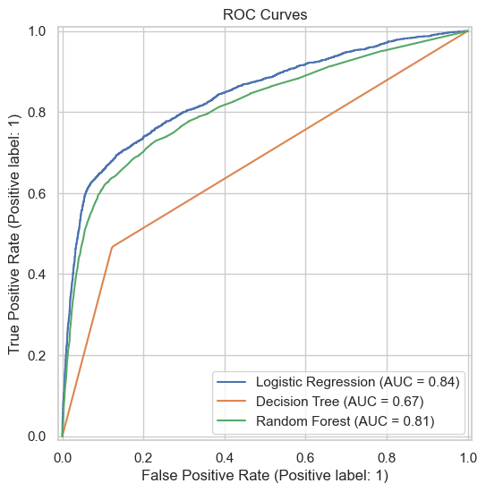

```python
models = {
    'Logistic Regression': logreg,
    'Decision Tree': dtree,
    'Random Forest': rf
}

# Evaluate models
for name, model in models.items():
    y_pred = model.predict(X_test)
    y_proba = model.predict_proba(X_test)[:, 1]

    print(f"--- {name} ---")
    print("Accuracy:", accuracy_score(y_test, y_pred))
    print("Precision:", precision_score(y_test, y_pred))
    print("Recall:", recall_score(y_test, y_pred))
    print("F1 Score:", f1_score(y_test, y_pred))
    print("ROC AUC:", roc_auc_score(y_test, y_proba))
    print("Confusion Matrix:\n", confusion_matrix(y_test, y_pred))
    print("\n")

# ROC curves
plt.figure(figsize=(8, 6))
for name, model in models.items():
    RocCurveDisplay.from_estimator(model, X_test, y_test, name=name, ax=plt.gca())

plt.title("ROC Curves")
plt.show()
```

```python
import pandas as pd
import numpy as np
import scipy.stats as stats
import statsmodels.api as sm
import statsmodels.formula.api as smf

# CHI-SQUARE TEST
# contingency table created
contingency = pd.crosstab(df_clean['cancer_dx'], df_clean['depression_dx'])

# chi
chi2, p, dof, expected = stats.chi2_contingency(contingency)

print("Chi-square test results:")
print("Chi-square statistic:", chi2)
print("Degrees of freedom:", dof)
print("P-value:", p)
print("\nContingency Table:")
print(contingency)

# LOGISTIC REGRESSION (depression_dx ~ cancer_dx + covariates)
# categorical variables
logit_model = smf.logit('depression_dx ~ cancer_dx + AGEP_A + C(SEX_A) + C(RACEALLP_A) + C(EDUC_A) + POVRATTC_A + C(PHSTAT_A) + anxiety_dx + C(UPPSLFCR_A)', data=df_clean)

# model fit
result = logit_model.fit()

# results
print("\nLogistic Regression Summary:")
print(result.summary())

# odds ratio 95% CI
params = result.params
conf = result.conf_int()
conf['OR'] = params
conf.columns = ['2.5%', '97.5%', 'OR']
conf = np.exp(conf)
print("\nOdds Ratios with 95% Confidence Intervals:")
print(conf)
```

```
Chi-square test results:
Chi-square statistic: 107.74431598986698
Degrees of freedom: 1
P-value: 3.0578814938180325e-25

Contingency Table:
depression_dx      0     1
cancer_dx
0              46194  9223
1               6259  1699
Warning: Maximum number of iterations has been exceeded.
         Current function value: 0.316783
         Iterations: 35

Logistic Regression Summary:
```

```
                           Logit Regression Results
==============================================================================
Dep. Variable:          depression_dx   No. Observations:                63375
Model:                          Logit   Df Residuals:                    63335
Method:                           MLE   Df Model:                           39
Date:                Sun, 13 Jul 2025   Pseudo R-squ.:                  0.3107
Time:                        01:45:32   Log-Likelihood:                -20076.
converged:                      False   LL-Null:                       -29126.
Covariance Type:            nonrobust   LLR p-value:                     0.000
======================================================================================
                         coef    std err          z      P>|z|      [0.025      0.975]
--------------------------------------------------------------------------------------
Intercept             -3.0877      0.288    -10.706      0.000      -3.653      -2.522
C(SEX_A)[T.2]          0.4822      0.027     17.656      0.000       0.429       0.536
C(SEX_A)[T.7]          1.5575      1.347      1.156      0.248      -1.083       4.198
C(SEX_A)[T.9]        -17.5047   1.95e+04     -0.001      0.999   -3.82e+04    3.81e+04
C(RACEALLP_A)[T.2]    -0.4277      0.046     -9.381      0.000      -0.517      -0.338
C(RACEALLP_A)[T.3]    -0.8398      0.080    -10.447      0.000      -0.997      -0.682
C(RACEALLP_A)[T.4]    -0.1332      0.137     -0.972      0.331      -0.402       0.135
C(RACEALLP_A)[T.5]     0.1245      0.122      1.020      0.308      -0.115       0.364
C(RACEALLP_A)[T.6]    -0.1330      0.121     -1.099      0.272      -0.370       0.104
C(RACEALLP_A)[T.7]    -0.0722      0.868     -0.083      0.934      -1.773       1.628
C(RACEALLP_A)[T.8]    -0.4226      0.069     -6.136      0.000      -0.558      -0.288
C(RACEALLP_A)[T.9]     0.4859      0.870      0.559      0.576      -1.219       2.191
C(EDUC_A)[T.1.0]       0.1676      0.285      0.588      0.557      -0.391       0.727
C(EDUC_A)[T.2.0]       0.1335      0.303      0.441      0.659      -0.460       0.727
C(EDUC_A)[T.3.0]       0.5415      0.292      1.855      0.064      -0.031       1.114
C(EDUC_A)[T.4.0]       0.1131      0.283      0.400      0.690      -0.442       0.668
C(EDUC_A)[T.5.0]       0.4546      0.284      1.603      0.109      -0.101       1.011
C(EDUC_A)[T.6.0]       0.1118      0.290      0.386      0.700      -0.456       0.680
C(EDUC_A)[T.7.0]       0.4067      0.285      1.427      0.154      -0.152       0.966
C(EDUC_A)[T.8.0]       0.3460      0.284      1.219      0.223      -0.210       0.902
C(EDUC_A)[T.9.0]       0.5181      0.286      1.814      0.070      -0.042       1.078
C(EDUC_A)[T.10.0]      0.8750      0.302      2.897      0.004       0.283       1.467
C(EDUC_A)[T.11.0]      0.9120      0.296      3.076      0.002       0.331       1.493
C(EDUC_A)[T.97.0]     -0.0095      0.465     -0.020      0.984      -0.921       0.902
C(EDUC_A)[T.99.0]      0.4133      0.348      1.189      0.234      -0.268       1.094
C(PHSTAT_A)[T.2]       0.5394      0.043     12.624      0.000       0.456       0.623
C(PHSTAT_A)[T.3]       0.9046      0.044     20.630      0.000       0.819       0.991
C(PHSTAT_A)[T.4]       1.4070      0.051     27.415      0.000       1.306       1.508
```

[output cut: 41 more lines]

```
C(PHSTAT_A)[T.2]     1.577140   1.864677  1.714892e+00
C(PHSTAT_A)[T.3]     2.267552   2.692837  2.471063e+00
C(PHSTAT_A)[T.4]     3.693010   4.515982  4.083818e+00
C(PHSTAT_A)[T.5]     4.686695   6.182824  5.383030e+00
C(PHSTAT_A)[T.7]     0.313330  20.299381  2.521985e+00
C(PHSTAT_A)[T.9]     1.170836  18.675573  4.676114e+00
C(UPPSLFCR_A)[T.2]   1.490746   1.910864  1.687783e+00
C(UPPSLFCR_A)[T.3]   1.222972   2.012570  1.568859e+00
C(UPPSLFCR_A)[T.4]   1.120959   2.200608  1.570602e+00
C(UPPSLFCR_A)[T.7]   0.000000        inf  1.072188e-12
C(UPPSLFCR_A)[T.9]   0.020063  16.323340  5.722734e-01
cancer_dx            1.057169   1.234152  1.142238e+00
AGEP_A               0.991755   0.994868  9.933104e-01
POVRATTC_A           0.934180   0.955128  9.445955e-01
anxiety_dx          17.076271  19.070738  1.804597e+01
```

The analysis reveals a statistically significant association between cancer diagnosis and depression. The Chi-square test confirms this link (χ² = 107.74, *p* < 0.001), and logistic regression—adjusting for demographics, socioeconomic status, anxiety, health status, and self-care difficulty—shows that individuals with cancer have 14% higher odds of depression (OR = 1.14, 95% CI: 1.06–1.23, *p* = 0.001). Strong predictors of depression include anxiety diagnosis (OR ≈ 18), poor self-reported health, and self-care limitations. Women also show higher odds of depression compared to men. Although the model had some convergence issues due to sparse data in certain categories, the overall findings consistently highlight that a history of cancer modestly but significantly increases the likelihood of depression.

```python
# Converting bools to int
X_fixed = X.astype({col: int for col in X.select_dtypes(include='bool').columns})

# Drop any remaining NA
X_fixed = X_fixed.dropna()

# Align y with X
y_aligned = y[X_fixed.index]

# Adding constant & running logistic regression
X_const = sm.add_constant(X_fixed)
logit_model = sm.Logit(y_aligned, X_const)
result = logit_model.fit()

# Odds ratios with C/I
odds_ratios = np.exp(result.params)
conf = np.exp(result.conf_int())
summary_df = pd.DataFrame({
    "Odds Ratio": odds_ratios,
    "2.5% CI": conf[0],
    "97.5% CI": conf[1],
    "p-value": result.pvalues
})
print(summary_df)
```

```
Warning: Maximum number of iterations has been exceeded.
         Current function value: 0.316750
         Iterations: 35
                Odds Ratio        2.5% CI       97.5% CI        p-value
const         7.629471e-01   0.000000e+00            inf   9.999997e-01
AGEP_A        8.829629e-01   8.579187e-01   9.087383e-01   2.280408e-17
POVRATTC_A    8.471547e-01   8.204275e-01   8.747526e-01   3.627865e-24
ANXEV_A       1.797226e-01   0.000000e+00            inf   9.999959e-01
cancer_dx     1.142109e+00   1.057055e+00   1.234007e+00   7.648535e-04
anxiety_dx    3.238837e+00   0.000000e+00            inf   9.999972e-01
SEX_A_2       1.619600e+00   1.535174e+00   1.708668e+00   9.651622e-70
SEX_A_7       4.826563e+00   3.410840e-01   6.829904e+01   2.442825e-01
SEX_A_9       2.361854e-08   0.000000e+00            inf   9.992891e-01
RACEALLP_A_2  6.518676e-01   5.961485e-01   7.127945e-01   6.205427e-21
RACEALLP_A_3  4.310956e-01   3.682303e-01   5.046933e-01   1.279728e-25
RACEALLP_A_4  8.754515e-01   6.693063e-01   1.145089e+00   3.315592e-01
RACEALLP_A_5  1.131330e+00   8.905404e-01   1.437225e+00   3.122279e-01
RACEALLP_A_6  8.751514e-01   6.904067e-01   1.109332e+00   2.703229e-01
RACEALLP_A_7  9.044469e-01   1.650598e-01   4.955927e+00   9.078740e-01
RACEALLP_A_8  6.545644e-01   5.719150e-01   7.491578e-01   7.576703e-10
RACEALLP_A_9  1.579291e+00   2.869281e-01   8.692626e+00   5.994736e-01
EDUC_A_1.0    1.179556e+00   6.744986e-01   2.062796e+00   5.625312e-01
EDUC_A_2.0    1.138377e+00   6.286354e-01   2.061451e+00   6.688128e-01
EDUC_A_3.0    1.713492e+00   9.670891e-01   3.035973e+00   6.499440e-02
EDUC_A_4.0    1.115156e+00   6.402916e-01   1.942197e+00   7.002149e-01
EDUC_A_5.0    1.569068e+00   9.000157e-01   2.735481e+00   1.121732e-01
EDUC_A_6.0    1.113745e+00   6.312465e-01   1.965045e+00   7.099894e-01
EDUC_A_7.0    1.494658e+00   8.548349e-01   2.613372e+00   1.586059e-01
EDUC_A_8.0    1.406109e+00   8.061082e-01   2.452702e+00   2.298803e-01
EDUC_A_9.0    1.668857e+00   9.534047e-01   2.921199e+00   7.298599e-02
EDUC_A_10.0   2.385895e+00   1.320087e+00   4.312210e+00   3.982501e-03
EDUC_A_11.0   2.477129e+00   1.385475e+00   4.428929e+00   2.215294e-03
EDUC_A_97.0   9.879815e-01   3.968245e-01   2.459796e+00   9.792729e-01
EDUC_A_99.0   1.506780e+00   7.624602e-01   2.977709e+00   2.381500e-01
PHSTAT_A_2    1.715427e+00   1.577602e+00   1.865294e+00   1.470611e-36
PHSTAT_A_3    2.472518e+00   2.268843e+00   2.694478e+00   1.238972e-94
PHSTAT_A_4    4.090299e+00   3.698780e+00   4.523262e+00  9.247150e-166
PHSTAT_A_5    5.398357e+00   4.699878e+00   6.200641e+00  9.995549e-126
PHSTAT_A_7    2.512639e+00   3.126851e-01   2.019077e+01   3.861929e-01
PHSTAT_A_9    4.654769e+00   1.166965e+00   1.856685e+01   2.935324e-02
UPPSLFCR_A_2  1.688735e+00   1.491594e+00   1.911931e+00   1.304798e-16
UPPSLFCR_A_3  1.566049e+00   1.220852e+00   2.008852e+00   4.145594e-04
UPPSLFCR_A_4  1.574305e+00   1.123736e+00   2.205533e+00   8.336438e-03
UPPSLFCR_A_7  3.019715e-05  3.751136e-287  2.430912e+277   9.749300e-01
UPPSLFCR_A_9  5.629312e-01   1.946414e-02   1.628079e+01   7.378369e-01
YEAR_2020     1.055618e+00   1.002571e+00   1.111471e+00   3.963209e-02
```

```
C:\Users\foram\anaconda3\Lib\site-packages\statsmodels\base\model.py:607: ConvergenceWarning: Maximum Likelihood optimization failed to converge. Check mle_retvals
  warnings.warn("Maximum Likelihood optimization failed to "
```

## Step 9 Code: Subgroup Modeling by Cancer Type

```python
from sklearn.metrics import classification_report

# Defining predictor features used in the main model
features = [
    'AGEP_A',
    'SEX_A',
    'RACEALLP_A',
    'EDUC_A',
    'POVRATTC_A',
    'PHSTAT_A',
    'anxiety_dx',
    'UPPSLFCR_A',
    'YEAR'
]

# Cancer type columns (exploratory subgroups)
cancer_type_columns = [
    'BREASCAN_A', 'COLONCAN_A', 'PROSTCAN_A', 'LUNGCAN_A', 'SKNMCAN_A'
]

# Looping through each cancer type
for cancer_col in cancer_type_columns:
    if cancer_col not in df.columns:
        print(f"Skipping {cancer_col} (not found in dataset)")
        continue

    print(f"\n--- Subgroup: {cancer_col.replace('_A','')} ---")

    # Filtering individuals with that specific cancer (value == 1)
    subgroup = df_clean[df[cancer_col] == 1]

    # insufficient data = skip
    if subgroup.shape[0] < 200:
        print(f"Too few cases ({subgroup.shape[0]}). Skipping.")
        continue

    # Define X and y
    X_sub = subgroup[features]
    y_sub = subgroup['depression_dx']

    # Train-test split
    X_train_sub, X_test_sub, y_train_sub, y_test_sub = train_test_split(
        X_sub, y_sub, test_size=0.2, random_state=42
    )

    # Train logistic regression
    model = LogisticRegression(max_iter=1000)
    model.fit(X_train_sub, y_train_sub)

    # Predict and evaluate
    y_pred_sub = model.predict(X_test_sub)
    print(classification_report(y_test_sub, y_pred_sub, zero_division=0))
```

```
--- Subgroup: BREASCAN ---
              precision    recall  f1-score   support

           0       0.89      0.93      0.91       234
           1       0.72      0.61      0.66        72

    accuracy                           0.85       306
   macro avg       0.80      0.77      0.78       306
weighted avg       0.85      0.85      0.85       306


--- Subgroup: COLONCAN ---
              precision    recall  f1-score   support

           0       0.96      0.96      0.96        72
           1       0.67      0.67      0.67         9

    accuracy                           0.93        81
   macro avg       0.81      0.81      0.81        81
weighted avg       0.93      0.93      0.93        81


--- Subgroup: PROSTCAN ---
              precision    recall  f1-score   support

           0       0.91      0.96      0.93       175
           1       0.50      0.29      0.37        24

    accuracy                           0.88       199
   macro avg       0.70      0.63      0.65       199
weighted avg       0.86      0.88      0.87       199


--- Subgroup: LUNGCAN ---
              precision    recall  f1-score   support

           0       0.78      0.89      0.83        36
           1       0.50      0.31      0.38        13

    accuracy                           0.73        49
   macro avg       0.64      0.60      0.61        49
weighted avg       0.71      0.73      0.71        49


--- Subgroup: SKNMCAN ---
              precision    recall  f1-score   support

           0       0.90      0.90      0.90       115
           1       0.59      0.61      0.60        28

    accuracy                           0.84       143
   macro avg       0.74      0.75      0.75       143
weighted avg       0.84      0.84      0.84       143
```

The subgroup analysis examined the predictive performance of logistic regression models for identifying depression among individuals diagnosed with specific types of cancer. Among breast cancer patients, the model showed the strongest performance, achieving 85% accuracy with a balanced precision of 72% and recall of 61%, indicating a reliable ability to detect depressive cases. For colon cancer, although the accuracy was high at 93%, the results are less stable due to the very small number of depressed cases (n=9), which limits generalizability. In prostate and lung cancer subgroups, the model's performance dropped significantly in detecting depression, with recall values of just 29% and 31%, respectively—implying many false negatives and limited utility in clinical screening. The model performed moderately well among individuals with skin melanoma, reaching 84% accuracy with a fair balance between precision (59%) and recall (61%). Overall, while the model performs reasonably well for breast cancer and skin melanoma patients, it struggles in smaller or more challenging subgroups like lung and prostate cancer, likely due to limited sample sizes or more complex depression-cancer interactions. This highlights the need for larger datasets and possibly more sophisticated models to improve detection in these subgroups.

```python
# Define models
logreg = LogisticRegression(max_iter=1000)
dtree = DecisionTreeClassifier(random_state=42)
rf= RandomForestClassifier(random_state=42)

# Fit models
logreg.fit(X_train, y_train)
dtree.fit(X_train, y_train)
rf.fit(X_train, y_train)
```

```
RandomForestClassifier(random_state=42)
```

```
Cleaned Data Preview:
```

|  | AGEP_A | SEX_A | RACEALLP_A | EDUC_A | POVRATTC_A | PHSTAT_A | ANXEV_A | UPPSLFCR_A | YEAR | depression_dx | cancer_dx | anxiety_dx |
| --- | --- | --- | --- | --- | --- | --- | --- | --- | --- | --- | --- | --- |
| 0 | 97 | 1 | 2 | 7.0 | 2.96 | 3 | 2 | 1 | 2019 | 0 | 0 | 0.0 |
| 1 | 28 | 2 | 1 | 6.0 | 2.97 | 1 | 2 | 1 | 2019 | 0 | 0 | 0.0 |
| 2 | 72 | 1 | 1 | 5.0 | 4.28 | 3 | 2 | 1 | 2019 | 0 | 1 | 0.0 |
| 3 | 60 | 1 | 8 | 7.0 | 7.13 | 2 | 2 | 1 | 2019 | 0 | 0 | 0.0 |
| 4 | 60 | 1 | 1 | 5.0 | 1.13 | 4 | 1 | 1 | 2019 | 1 | 0 | 1.0 |

```
=== Logistic Regression ===
              precision    recall  f1-score   support

           0       0.91      0.96      0.93     10491
           1       0.71      0.54      0.61      2184

    accuracy                           0.88     12675
   macro avg       0.81      0.75      0.77     12675
weighted avg       0.88      0.88      0.88     12675


=== Decision Tree ===
              precision    recall  f1-score   support

           0       0.89      0.88      0.88     10491
           1       0.44      0.46      0.45      2184

    accuracy                           0.81     12675
   macro avg       0.66      0.67      0.67     12675
weighted avg       0.81      0.81      0.81     12675


=== Random Forest ===
              precision    recall  f1-score   support

           0       0.90      0.95      0.92     10491
           1       0.66      0.50      0.57      2184

    accuracy                           0.87     12675
   macro avg       0.78      0.72      0.74     12675
weighted avg       0.86      0.87      0.86     12675
```

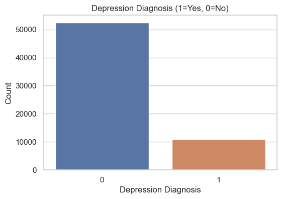

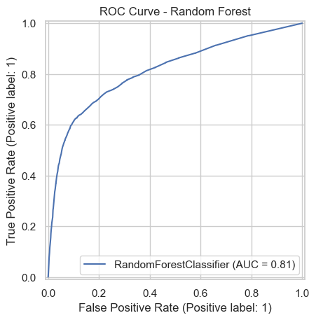

```python
from sklearn.metrics import classification_report, RocCurveDisplay

# 1. cleaned Data Summary
print("Cleaned Data Preview:")
display(df_clean.head())

# 2. Classification Report
print("=== Logistic Regression ===")
print(classification_report(y_test, logreg.predict(X_test)))

print("\n=== Decision Tree ===")
print(classification_report(y_test, dtree.predict(X_test)))

print("\n=== Random Forest ===")
print(classification_report(y_test, rf.predict(X_test)))

# 3. Class Balance Plot
plt.figure(figsize=(6, 4))
sns.countplot(x='depression_dx', data=df_clean)
plt.title("Depression Diagnosis (1=Yes, 0=No)")
plt.xlabel("Depression Diagnosis")
plt.ylabel("Count")
plt.show()

# 4.ROC Curve for Random Forest
RocCurveDisplay.from_estimator(rf, X_test, y_test)
plt.title("ROC Curve - Random Forest")
plt.show()
```

The analysis explores depression diagnosis prediction using machine learning models on a large health dataset. The class distribution plot reveals that a significantly larger portion of the sample did not have a depression diagnosis (coded as 0), highlighting class imbalance. Three models were evaluated: logistic regression, decision tree, and random forest. Logistic regression achieved the highest accuracy (88%) and AUC (0.84), indicating strong discriminatory power. The random forest followed closely with an accuracy of 87% and AUC of 0.81, offering improved precision over the decision tree, which had the lowest performance (accuracy of 81% and AUC of 0.67). Among all, logistic regression balanced recall and precision effectively, especially for the positive class (depression). The ROC curve for the random forest illustrates its robust predictive ability, confirming it as a competitive model. Overall, while logistic regression slightly outperformed in general, both it and the random forest were suitable for depression prediction, with the latter offering more flexibility and feature importance insights.